# 02_10_R_PCA_cars_dataset

## Predictive Modeling with PCA components

# Train / Test Split

After we’ve calculated the principal components on training set, let’s now understand the process of predicting on test data using these components. The process is simple. Just like we’ve obtained PCA components on training set, we’ll get another bunch of components on testing set. Finally, we train the model.

But, few important points to understand:

We should not combine the train and test set to obtain PCA components of whole data at once. Because, this would violate the entire assumption of generalization since test data would get ‘leaked’ into the training set. In other words, the test data set would no longer remain ‘unseen’. Eventually, this will hammer down the generalization capability of the model. We should not perform PCA on test and train data sets separately. Because, the resultant vectors from train and test PCAs will have different directions ( due to unequal variance). Due to this, we’ll end up comparing data registered on different axes. Therefore, the resulting vectors from train and test data should have same axes.

We should do exactly the same transformation to the test set as we did to training set, including the center and scaling feature. Let’s do it in R:

```r
# put classifier back to train set
train_data <- data.frame(target_class=pca.train$target_class,prin_comp$x)
```

```r
#we are interested in first 6 PCAs
train_data <- train_data[,1:7]
```

```r
#run a decision tree
#install.packages("rpart")
library(rpart)
rpart.model <- rpart(target_class~ .,data = train_data, method = "anova")
rpart.model
```

```
## n= 14318
##
## node), split, n, deviance, yval
##       * denotes terminal node
##
## 1) root 14318 1218.654000 0.093937700
##   2) PC1< 2.806277 13130  240.428400 0.018659560
##     4) PC5>=-1.487643 12892   12.986890 0.001008377 *
##     5) PC5< -1.487643 238    5.848739 0.974789900 *
##   3) PC1>=2.806277 1188   81.481480 0.925925900
##     6) PC4< -1.299098 69    2.869565 0.043478260 *
##     7) PC4>=-1.299098 1119   21.567470 0.980339600 *
```

```r
#transform test into PCA
test.data <- predict(prin_comp, newdata = pca.test)
test.data <- as.data.frame(test.data)
```

```r
#select the first 6 components
test.data <- test.data[,1:6]
```

```r
#make prediction on test data
rpart.prediction <- predict(rpart.model, test.data)
```

```r
#For fun, finally check your score of leaderboard
#sample <- read.csv("pulsar_stars.csv")

final.sub <- data.frame(Item_Identifier = pca.test$target_class, target_class = pca.test$target_class, predicted_class = rpart.prediction)
write.csv(final.sub, "pca2.csv",row.names = F)
```

# check what went in a file:

```r
head(final.sub, 45)
```

```
##     Item_Identifier target_class predicted_class
## 5                 0            0     0.001008377
## 10                0            0     0.001008377
## 13                0            0     0.001008377
## 14                0            0     0.001008377
## 17                0            0     0.001008377
## 22                0            0     0.001008377
## 27                0            0     0.001008377
## 30                0            0     0.001008377
## 31                0            0     0.001008377
## 33                0            0     0.001008377
## 34                0            0     0.001008377
## 35                0            0     0.001008377
## 37                0            0     0.001008377
## 41                0            0     0.001008377
```

[output cut: 31 more lines]

```r
#rounded error
round(mean((rpart.prediction - pca.test$target_class)^2),5)
```

```
## [1] 0.00165
```

## Plots of observations

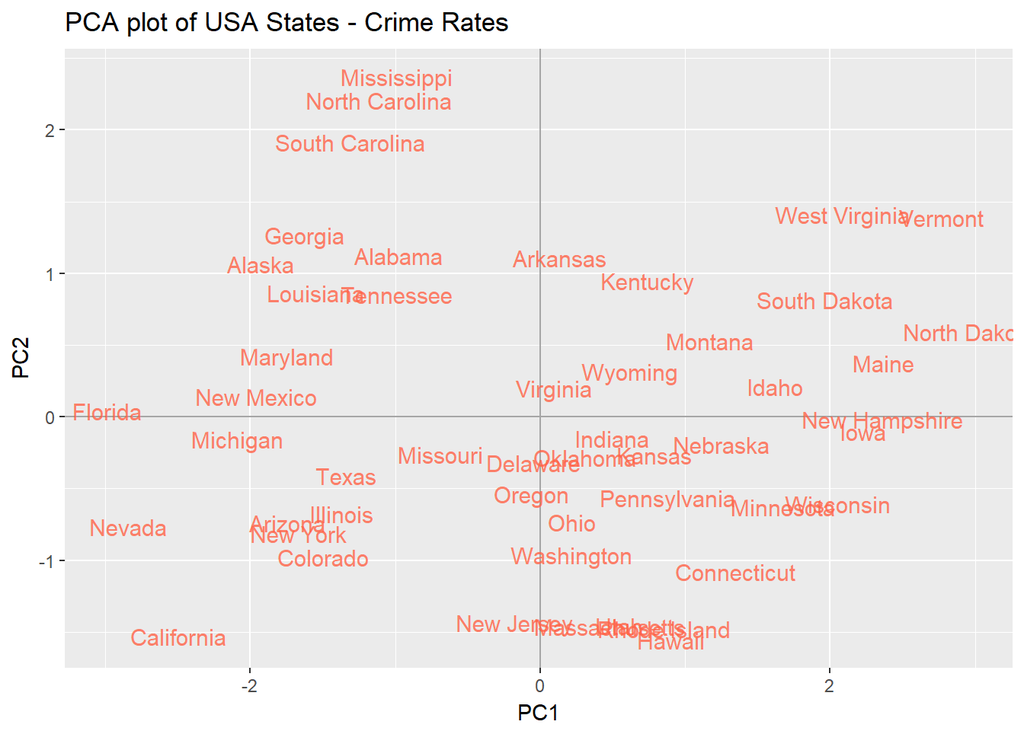

```r
# PCA with function prcomp
#With parameter scale. = T, we normalize the variables to have standard deviation equals to 1
pca1 = prcomp(USArrests, scale. = TRUE)

# load ggplot2
library(ggplot2)

# create data frame with scores
scores = as.data.frame(pca1$x)

# plot of observations
ggplot(data = scores, aes(x = PC1, y = PC2, label = rownames(scores))) +
  geom_hline(yintercept = 0, colour = "gray65") +
  geom_vline(xintercept = 0, colour = "gray65") +
  geom_text(colour = "tomato", alpha = 0.8, size = 4) +
  ggtitle("PCA plot of USA States - Crime Rates")
```

```r
head(USArrests)
```

```
##            Murder Assault UrbanPop Rape
## Alabama      13.2     236       58 21.2
## Alaska       10.0     263       48 44.5
## Arizona       8.1     294       80 31.0
## Arkansas      8.8     190       50 19.5
## California    9.0     276       91 40.6
## Colorado      7.9     204       78 38.7
```

```r
head(pca1)
```

```
## $sdev
## [1] 1.5748783 0.9948694 0.5971291 0.4164494
##
## $rotation
##                 PC1        PC2        PC3         PC4
## Murder   -0.5358995  0.4181809 -0.3412327  0.64922780
## Assault  -0.5831836  0.1879856 -0.2681484 -0.74340748
## UrbanPop -0.2781909 -0.8728062 -0.3780158  0.13387773
## Rape     -0.5434321 -0.1673186  0.8177779  0.08902432
##
## $center
##   Murder  Assault UrbanPop     Rape
##    7.788  170.760   65.540   21.232
##
## $scale
##    Murder   Assault  UrbanPop      Rape
##  4.355510 83.337661 14.474763  9.366385
##
## $x
##                        PC1         PC2         PC3          PC4
## Alabama        -0.97566045  1.12200121 -0.43980366  0.154696581
## Alaska         -1.93053788  1.06242692  2.01950027 -0.434175454
## Arizona        -1.74544285 -0.73845954  0.05423025 -0.826264240
## Arkansas        0.13999894  1.10854226  0.11342217 -0.180973554
## California     -2.49861285 -1.52742672  0.59254100 -0.338559240
## Colorado       -1.49934074 -0.97762966  1.08400162  0.001450164
## Connecticut     1.34499236 -1.07798362 -0.63679250 -0.117278736
## Delaware       -0.04722981 -0.32208890 -0.71141032 -0.873113315
## Florida        -2.98275967  0.03883425 -0.57103206 -0.095317042
## Georgia        -1.62280742  1.26608838 -0.33901818  1.065974459
## Hawaii          0.90348448 -1.55467609  0.05027151  0.893733198
## Idaho           1.62331903  0.20885253  0.25719021 -0.494087852
## Illinois       -1.36505197 -0.67498834 -0.67068647 -0.120794916
## Indiana         0.50038122 -0.15003926  0.22576277  0.420397595
## Iowa            2.23099579 -0.10300828  0.16291036  0.017379470
## Kansas          0.78887206 -0.26744941  0.02529648  0.204421034
## Kentucky        0.74331256  0.94880748 -0.02808429  0.663817237
## Louisiana      -1.54909076  0.86230011 -0.77560598  0.450157791
## Maine           2.37274014  0.37260865 -0.06502225 -0.327138529
## Maryland       -1.74564663  0.42335704 -0.15566968 -0.553450589
```

[output cut: 15 more lines]

```
## Oklahoma        0.30864928 -0.28496113 -0.01515592  0.010228476
## Oregon         -0.05852787 -0.53596999  0.93038718 -0.235390872
## Pennsylvania    0.87948680 -0.56536050 -0.39660218  0.355452378
## Rhode Island    0.85509072 -1.47698328 -1.35617705 -0.607402746
## South Carolina -1.30744986  1.91397297 -0.29751723 -0.130145378
## South Dakota    1.96779669  0.81506822  0.38538073 -0.108470512
## Tennessee      -0.98969377  0.85160534  0.18619262  0.646302674
## Texas          -1.34151838 -0.40833518 -0.48712332  0.636731051
## Utah            0.54503180 -1.45671524  0.29077592 -0.081486749
## Vermont         2.77325613  1.38819435  0.83280797 -0.143433697
## Virginia        0.09536670  0.19772785  0.01159482  0.209246429
## Washington      0.21472339 -0.96037394  0.61859067 -0.218628161
## West Virginia   2.08739306  1.41052627  0.10372163  0.130583080
## Wisconsin       2.05881199 -0.60512507 -0.13746933  0.182253407
## Wyoming         0.62310061  0.31778662 -0.23824049 -0.164976866
```